# Enhanced annotation of a primate phylogeny with ggtree

2017-05-21

The `ggtree` package on [Bioconductor](https://www.bioconductor.org/packages/devel/bioc/vignettes/ggtree/inst/doc/ggtree.html) is a welcome extension of `ggplot2` for visualizing and annotating phylogenies. Its best feature is the ability to easily annotate trees with text, labels, images, and most excitingly, plots within plots (i.e., *subplots*). For example, you can annotate internal nodes with histograms to display posterior distributions of continuous ancestral state estimates, or you can annotate tips with scatterplots depicting within-speies allometric relationships.

In this tutorial, I build some fancy primate phylogeny plots that demonstrate the features of `ggtree` I have found most useful for displaying comparative data and the results of ancestral state reconstructions (ASRs). Although I don’t cover the full breadth of the `ggtree` vignette, I do go a bit beyond the vignette in a couple of places (e.g., providing a function to annotate multiple nodes with different external images). A thorough overview of `ggtree` capabilities can be found in the package [vignette](http://www.bioconductor.org/packages/3.1/bioc/vignettes/ggtree/inst/doc/ggtree.html), and tutorials written by the package author [here](https://www.bioconductor.org/packages/devel/bioc/vignettes/ggtree/inst/doc/treeAnnotation.html#color-tree) and [here](https://www.bioconductor.org/packages/devel/bioc/vignettes/ggtree/inst/doc/advanceTreeAnnotation.html).

### Preparations

Install `phytools` from CRAN, and `EBImage` and `ggtree` from Bioconductor. Then load the packages:

```r
# install from CRAN
install.packages("phytools")

# install from Bioconductor
source("https://bioconductor.org/biocLite.R")
biocLite("EBImage")
biocLite("ggtree")

# load packages
library("phytools") # for sims and ASRs
library("EBImage") # for images
library("ggtree")
```

Import the primate phylogeny from GitHub (this tree originally came from [10kTrees](https://10ktrees.fas.harvard.edu/)):

```r
# read the tree from GitHub
tree <- read.nexus("https://raw.githubusercontent.com/rgriff23/Dissertation/master/Chapter_2/data/tree.nex")
```

### Basics

The simplest `ggtree` plot displays only branches:

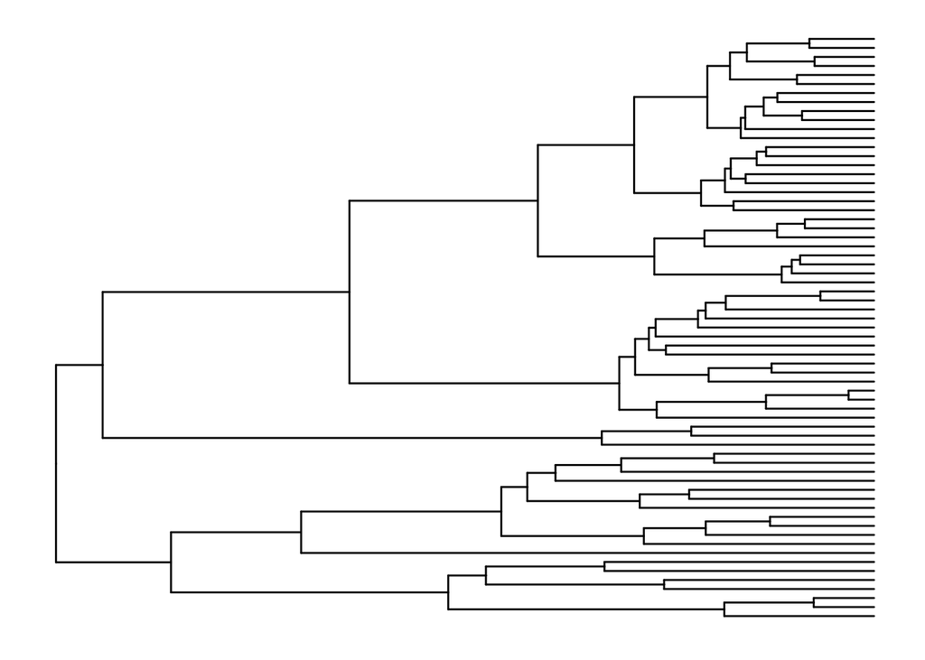

```r
# basic plot
p1 <- ggtree(tree)
plot(p1)
```

The layouts available in `ggtree` are the same as those available in `ape`’s `plot.phylo` function, although the names are different. Here are all the layouts, and also a demonstration of how to put multiple phylogenies in one plot using the `multiplot` function:

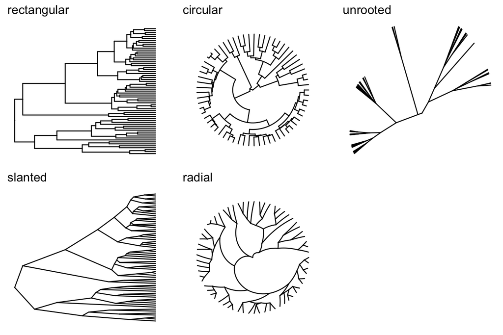

```r
# show different layouts in multiplot
p2a <- ggtree(tree, layout="rectangular") + ggtitle("rectangular")
p2b <- ggtree(tree, layout="slanted") + ggtitle("slanted")
p2c <- ggtree(tree, layout="circular") + ggtitle("circular")
p2d <- ggtree(tree, layout="radial") + ggtitle("radial")
p2e <- ggtree(tree, layout="unrooted") + ggtitle("unrooted")
multiplot(p2a, p2b, p2c, p2d, p2e, ncol=3)
```

We have to add all other features related to the nodes, tips, and branches. This can be done by adding layers to the basic plot:

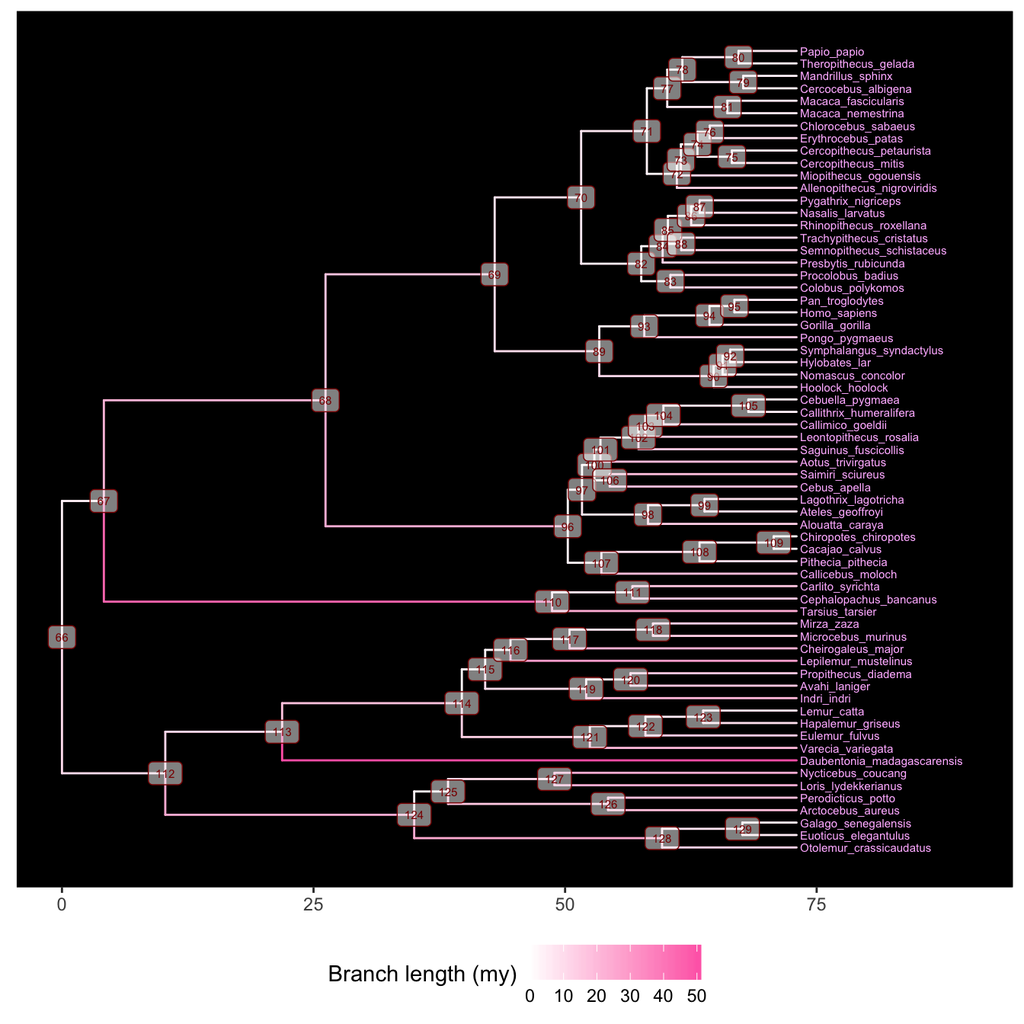

```r
# add tip labels (making room with xlim first), node labels, background color,
# branch colors (based on branch legths), and a legend for the branch colors
p3 <- ggtree(tree, aes(color=branch.length)) +
  xlim(0, 90) +
  geom_tiplab(size=2, color="plum1") +
  geom_label2(aes(subset=!isTip, label=node), size=2, color="darkred", alpha=0.5) +
  theme_tree2("black") +
  scale_color_continuous(low='white', high='hotpink', name="Branch length (my)") +
  theme(legend.position="bottom")
plot(p3)
```

This plot is useful for identifying the node numbers necessary to label or draw attention to clades in the next section.

### Annotating clades

Using the last plot, we can find the internal node numbers corresponding to the primate superfamilies:

- Node 124: Galagoidea
- Node 113: Lemuroidea
- Node 110: Tarsioidea
- Node 96: Ceboidea
- Node 89: Hominoidea
- Node 70: Cercopithecoidea

There are a couple of approaches we can take to delineate the clades of interest. One is to add shaded regions around them:

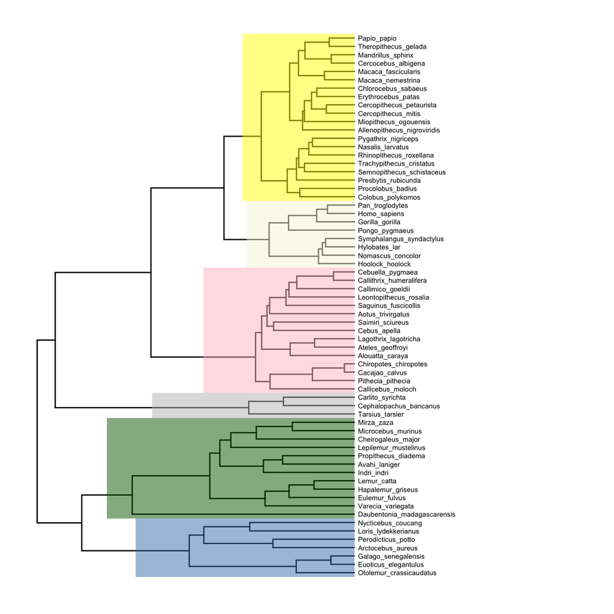

```r
# highlight clades
p4 <- ggtree(tree) +
  xlim(0, 125) +
  geom_tiplab(size=2, offset=0.5) +
  geom_hilight(node=124, fill="steelblue", alpha=0.5) +
  geom_hilight(node=113, fill="darkgreen", alpha=0.5) +
  geom_hilight(node=110, fill="gray", alpha=0.5) +
  geom_hilight(node=96, fill="pink", alpha=0.5) +
  geom_hilight(node=89, fill="beige", alpha=0.5) +
  geom_hilight(node=70, fill="yellow", alpha=0.5)
plot(p4)
```

Another would be to add labeled bars near the tips of the tree that show the extent of each clade (note how I adjust the text size and position for the small Tarsiidae family):

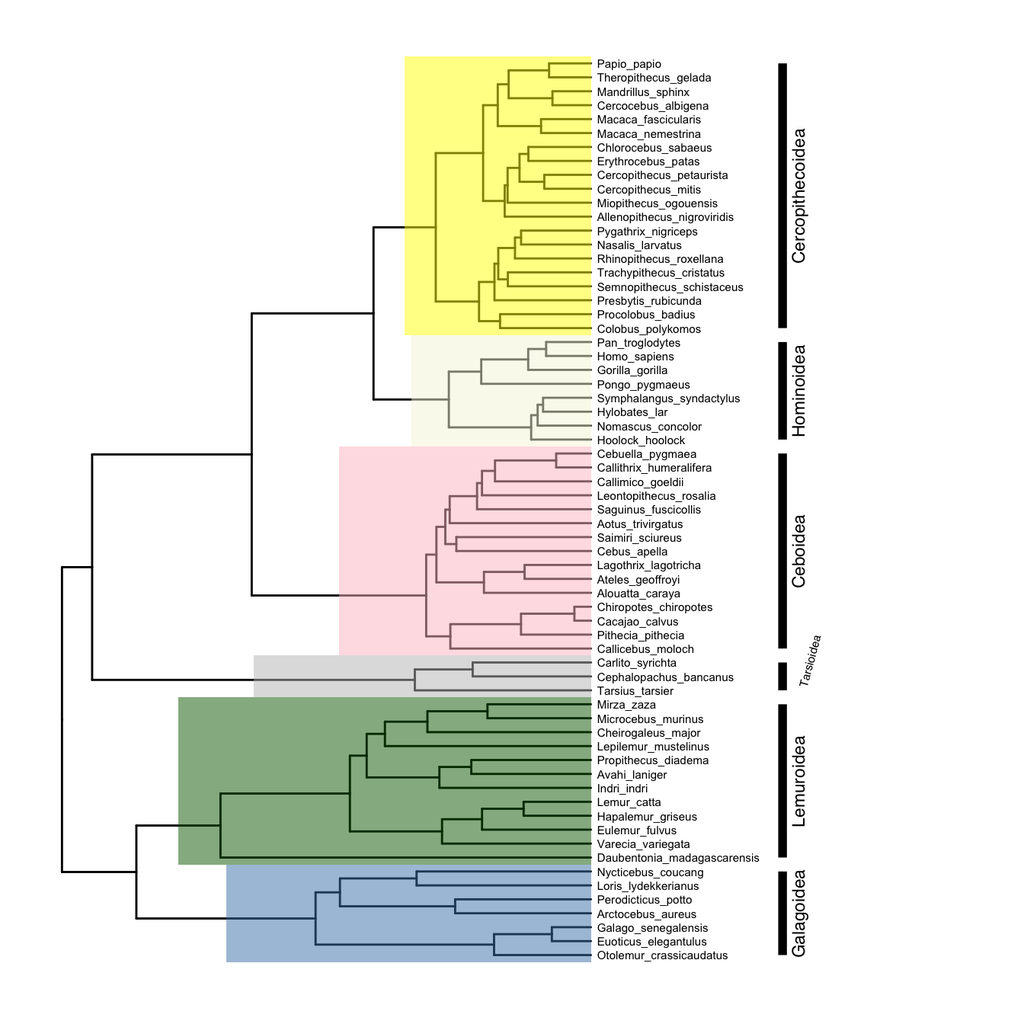

```r
# label clades
p5 <- p4 +
  geom_cladelabel(124, "Galagoidea", offset=25, barsize=2, angle=90, offset.text=1.5, hjust=0.5, fontsize=3) +
  geom_cladelabel(113, "Lemuroidea", offset=25, barsize=2, angle=90, offset.text=1.5, hjust=0.5, fontsize=3) +
  geom_cladelabel(110, "Tarsioidea", offset=25, barsize=2, angle=75, offset.text=2.5, hjust=0.2, fontsize=2) +
  geom_cladelabel(96, "Ceboidea", offset=25, barsize=2, angle=90, offset.text=1.5, hjust=0.5, fontsize=3) +
  geom_cladelabel(89, "Hominoidea", offset=25, barsize=2, angle=90, offset.text=1.5, hjust=0.5, fontsize=3) +
  geom_cladelabel(70, "Cercopithecoidea", offset=25, barsize=2, angle=90, offset.text=1.5, hjust=0.5, fontsize=3)
plot(p5)
```

- Galagoidea (124): “7fb9bea8-e758-4986-afb2-95a2c3bf983d”
- Lemuroidea (113): “bac25f49-97a4-4aec-beb6-f542158ebd23”
- Tarsioidea (110): “f598fb39-facf-43ea-a576-1861304b2fe4”
- Ceboidea (96): “aceb287d-84cf-46f1-868c-4797c4ac54a8”
- Hominoidea (89): “0174801d-15a6-4668-bfe0-4c421fbe51e8”
- Cercopithecoidea (70): “72f2f854-f3cd-4666-887c-35d5c256ab0f”

Now add the images to the plot.

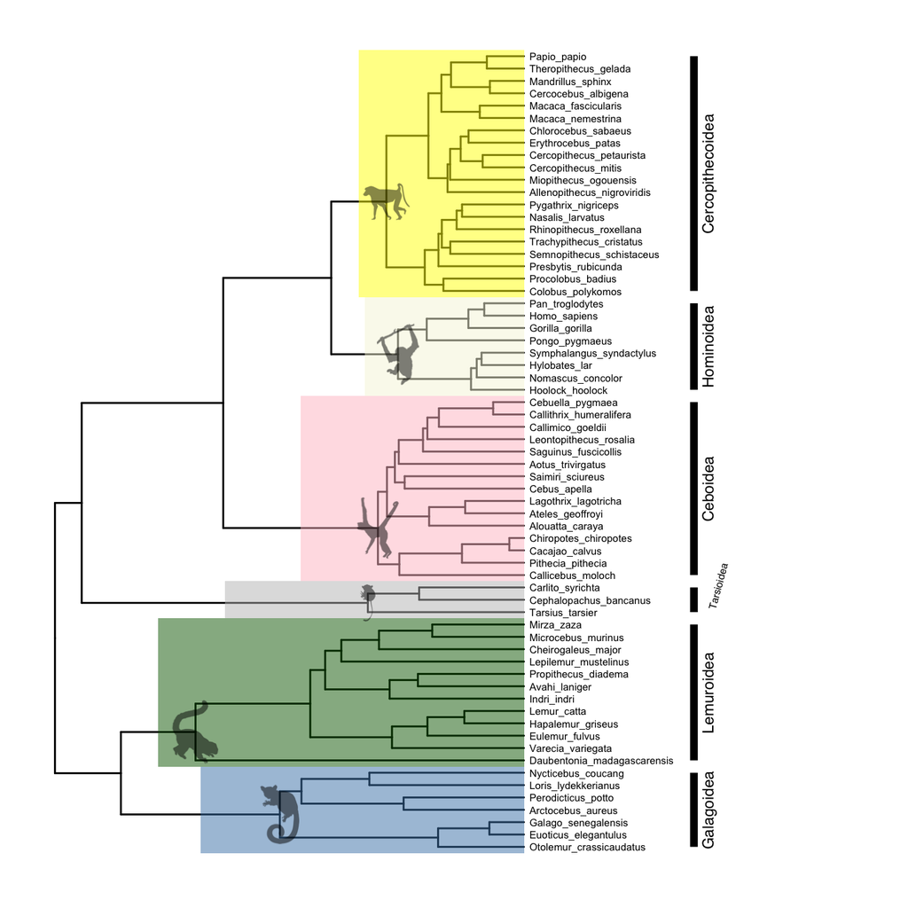

```r
# add phylopic images
p6 <- phylopic(p5, "7fb9bea8-e758-4986-afb2-95a2c3bf983d", node=124) # galagoids
p6 <- phylopic(p6, "bac25f49-97a4-4aec-beb6-f542158ebd23", node=113) # lemurs
p6 <- phylopic(p6, "f598fb39-facf-43ea-a576-1861304b2fe4", node=110) # tarsiers
p6 <- phylopic(p6, "aceb287d-84cf-46f1-868c-4797c4ac54a8", node=96) # cebids
p6 <- phylopic(p6, "0174801d-15a6-4668-bfe0-4c421fbe51e8", node=89) # hominoids
p6 <- phylopic(p6, "72f2f854-f3cd-4666-887c-35d5c256ab0f", node=70) # cercopithecoids
plot(p6)
```

Adding images from sources other than `phylopic` is a bit annoying to code, but it is possible. There is some code in the package author’s [“Advance Tree Annotation” tutorial](https://www.bioconductor.org/packages/devel/bioc/vignettes/ggtree/inst/doc/advanceTreeAnnotation.html) that shows how to add a single external image to multiple nodes, but the code does not make it easy to add multiple different images to different at once. I managed to do it by writing a function that loops over vectors node numbers and urls of the images you want to add, and iteratively adds them to a plot using the `inset` function. Here is how I added Pokemon node labels from images on `imgur`:

[figure not shown]

```r
# define function for adding external images to nodes
add.images <- function (plot, nodes, images) {
  p <- plot
  for (i in 1:length(images)) {
   imgfile <- tempfile(, fileext=".png")
   download.file(images[i], destfile=imgfile, mode='wb')
   names(imgfile) <- nodes[i]
   p <- inset(p, imgfile)
  }
  return(p)
}

# define vector with node numbers as character strings
nodes <- c("70","89","96","110","113","124")

# define vector with urls to images
images <- c("https://i.imgur.com/8VA9cYw.png",
            "https://i.imgur.com/XYM1T2x.png",
            "https://i.imgur.com/EQs5ZZe.png",
            "https://i.imgur.com/2xin0UK.png",
            "https://i.imgur.com/hbftayl.png",
            "https://i.imgur.com/3wDHW8n.png")

# add images
p7 <- add.images(p5, nodes, images)

# plot
plot(p7)
```

In case you are wondering, that is in fact my winning team from Pokemon Blue Version in the early 2000s.

### Annotating tips with comparative data

Simulate some comparative data with `phytools`- let’s do 5 continuous Brownian motion traits:

```r
# simulate 5 continous BM traits
set.seed(23) # reproducible
traits <- data.frame(fastBM(tree, nsim=5))
```

We can use `gheatmap` to display the data matrix:

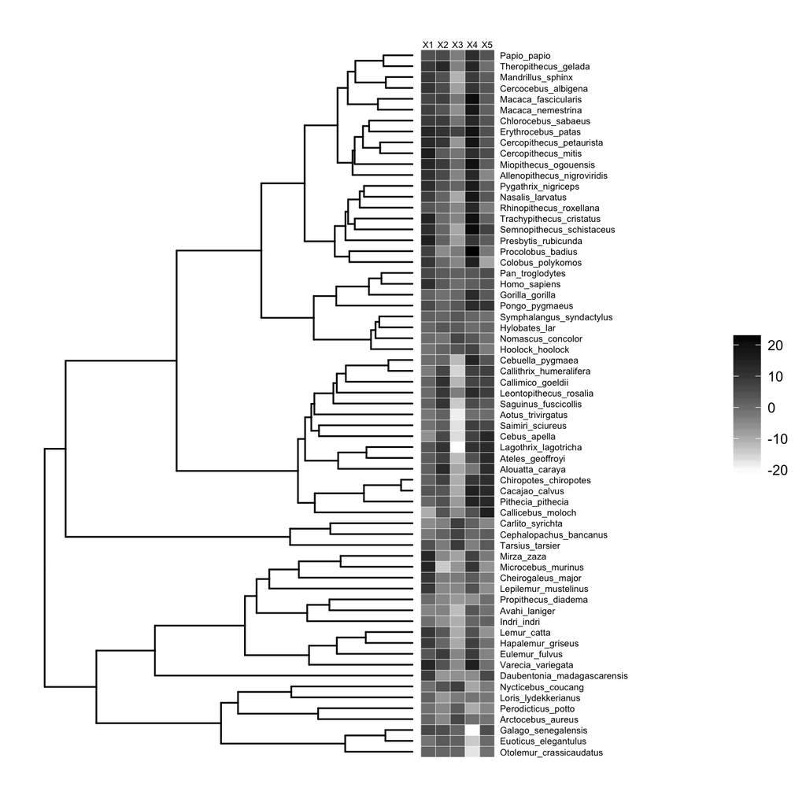

```r
# basic plot
p8 <- ggtree(tree) +
  xlim(0, 125) +
  geom_tiplab(size=2, offset=17)

# add heatmap
p9 <-  gheatmap(p8, traits, offset=0.2, width=0.2, low="white", high="black", colnames_position = "top", font.size=2)

# plot
plot(p9)
```

This works just as well if our traits are binary, e.g., presence-absence data.

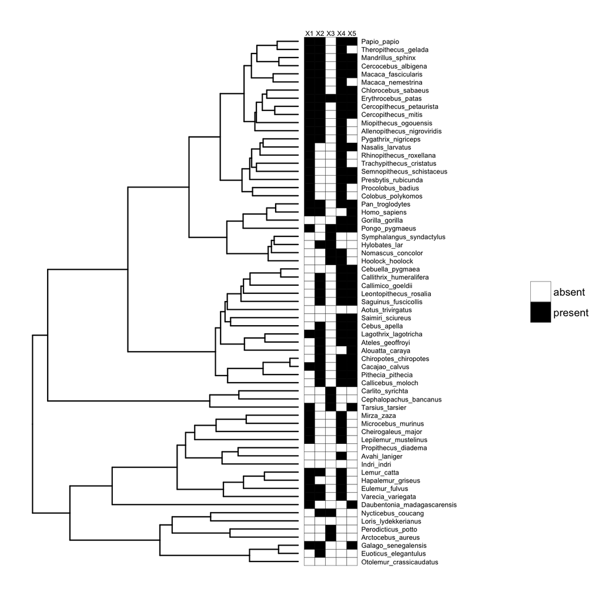

```r
# make traits binary
traits.binary <- data.frame(matrix(ifelse(stack(traits)$values > mean(stack(traits)$values), "present", "absent"), 65, 5))
row.names(traits.binary) <- row.names(traits)

# add heatmap
p10 <-  gheatmap(p8, traits.binary, offset=0.2, width=0.2, low="white", high="black", colnames_position = "top", font.size=2, color="black") +
    scale_fill_manual(values=c("white", "black"))

# plot
plot(p10)
```

What if instead of having multiple variables per species, we have within-species samples for a single variable (e.g., multiple body mass measures for each species), and we want to display the distribution of that variable for each species? This brings us to the biggest advantage of `ggtree`: the ability to create plots within your phylogeny plots, or ‘subplots’.

Figures with subplots can quickly become overcrowded, so I will first trim the tree to just 6 primates, and then simulate continuous within-species data distributions for each species:

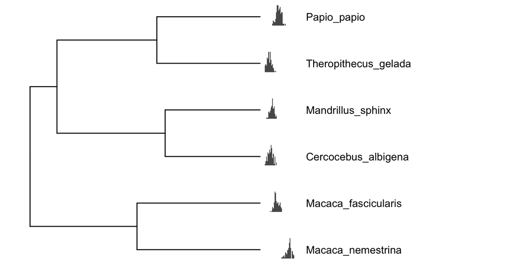

```r
# extract subtree with 6 species
sub <- extract.clade(tree, 77)

# simulate within-species variation
means <- fastBM(sub, nsim=1)
d <- lapply(means, rnorm, n=100)
bx <- lapply(d, function(y) {
    ggplot(data.frame(y=y), aes(y)) +
    geom_histogram(binwidth = 0.3) +
    xlim(range(unlist(d))) +
    theme_inset()
})

# names need to be node/tip numbers
names(bx) <- 1:length(means)

# plot trees with continuous and discrete tip data
psub <- ggtree(sub) +
  xlim(0,25) +
  geom_tiplab(offset=2.5, size=4)
inset(psub, bx, width=0.2, height=0.15, hjust=-1)
```

Note that we used the `inset` function to add the subplots, which is the same function we used earlier to add external images to nodes. We will use `inset` again when we display the results of ancestral state reconstructions at internal nodes. In general, `inset` accepts a list of `ggplot` graphic objects (they need not be the same type of object) and adds them to a `ggtree` plot. You can add any `ggplot` object you wish to your plot using this function.

### Displaying ASRs with subplots

Now we will simulate a single continuous trait and perform ancestral state reconstructions (ASRs) and visualize the results across nodes. First, estimate the ASRs for the first continuous trait in our original data, using the `anc.Bayes` function from `phytools`:

```r
# simulate single trait
set.seed(23) # reproducible
trait <- fastBM(tree)

# estimate continuous ASRs with Bayesian Brownian motion model
asr.cont <- anc.Bayes(tree, trait)
```

[output not shown]

For the continuous trait, ancestral states are represented by continuous posterior distributions that can be visualized with histograms. We can annotate our nodes of interest with histograms of the corresponding posterior distributions:

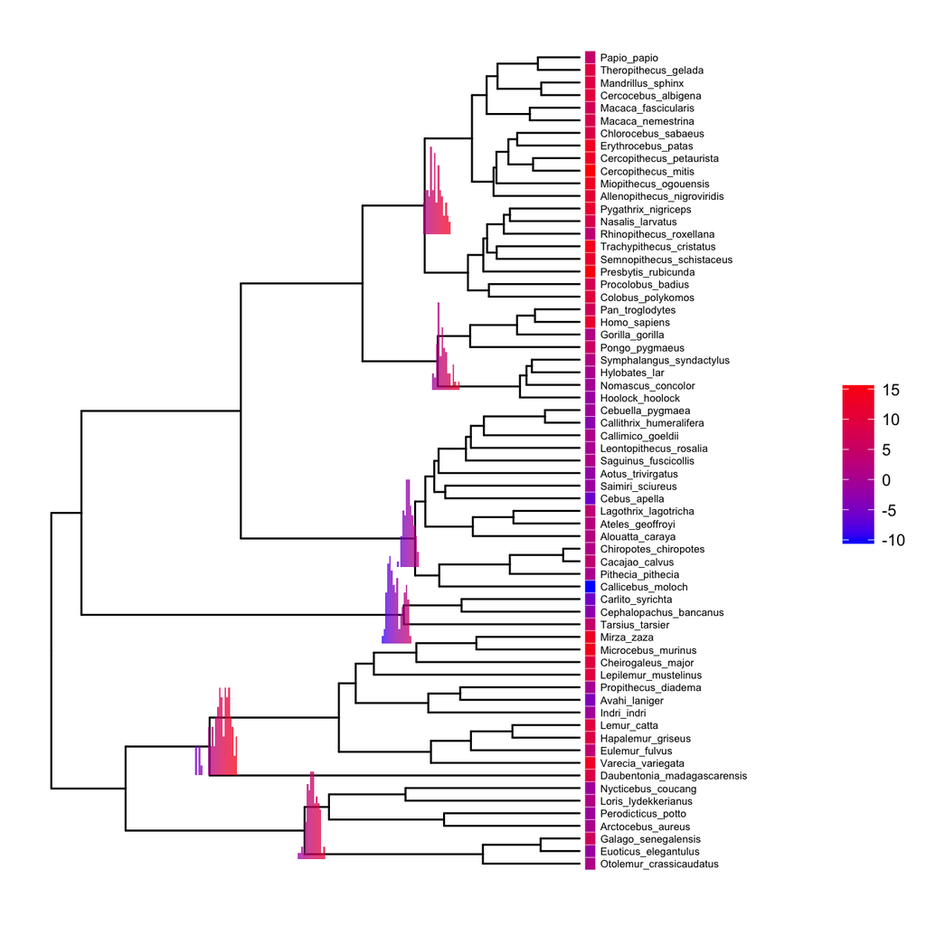

```r
# basic plot
p11 <- ggtree(tree) +
  xlim(0,100) +
  geom_tiplab(offset=2.5, size=2)
p11 <-  gheatmap(p11, data.frame(trait), width=0.02, low="blue", high="red", colnames = FALSE)

# define vector with node numbers as character strings
nodes <- c("70","89","96","110","113","124")

# add continuous ASR posterior distributions for selected nodes
pd <- asr.cont[,nodes]
pdplots <- apply(pd, 2, function(y) {
    ggplot(data.frame(y=y), aes(y, fill=..x..)) +
    geom_histogram(binwidth = 0.5, alpha=0.75) +
    xlim(range(unlist(pd))) +
    scale_fill_gradient(low = "blue", high = "red") +
    theme_inset()
})

# plot
inset(p11, pdplots, width=0.15, height=0.15, vjust=-1)
```

Note that setting the aesthetic `fill=..x..` and using `scale_fill_gradient` with the same low and high colors as our `gheatmap` allows us to plot minimalistic histograms that use color shading to achieve what we usually achieve with an x-axis.

If we have ancestral state reconstructions for a discrete trait, ancestral states can be represented by a pie chart or bar chart depicting the relative probability of each state. Let’s use a continuous time Markov model to reconstruct ancestral states for our first discrete character, and visualize the results with pie charts at each internal node:

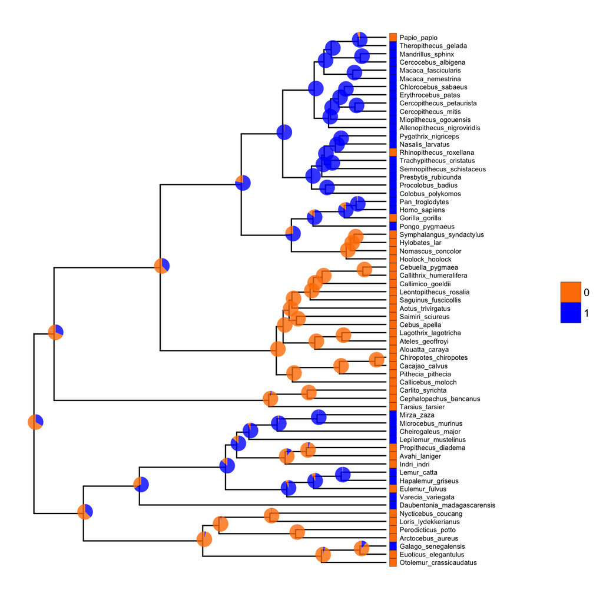

```r
# make trait binary
trait.bi <- ifelse(trait > mean(trait), 1, 0)

# estimate discrete ASRs with
asr.bi <- data.frame(rerootingMethod(tree, trait.bi)$marginal.anc)

# add column of node numbers
asr.bi$node <- row.names(asr.bi)

# basic tree
p12 <- ggtree(tree) +
  xlim(0,100) +
  geom_tiplab(offset=2.5, size=2)

# add heatmap
p12 <- gheatmap(p12, data.frame(factor(trait.bi)), offset=0.02, width=0.02, low="darkorange1", high="blue", colnames = FALSE, font.size=2, color="black") +
  scale_fill_manual(values=c("darkorange1","blue"))

# plot discrete ASRs with pie charts
pies <- nodepie(asr.bi, cols=1:2, color=c("darkorange1","blue"), alpha=0.8)
p12 <- inset(p12, pies)
plot(p12)
```

### Concluding remarks

If you are in the business of plotting phylogenies, mastering `ggtree` is well worth the effort. The downsides are that there is a learning curve if you are not familiar with `ggplot`, and it can be a little harder to find help because it isn’t as widely used alternatives (e.g., `plot.phylo` from the `ape` package). I note that [`phytools`](http://blog.phytools.org/) (which we used here to simulate data and reconstruct ancestral states) also has some interesting functions for visualizing phylogenetic comparative data and ancestral state reconstructions- see this [demo](https://lukejharmon.github.io/ilhabela/instruction/2015/07/05/plotting-methods/). However, as a general R toolkit for annotating phylogenies, `ggtree` is by far the most powerful and flexible option I am aware of.

**Footnotes**

Yu G, Smith D, Zhu H, Guan Y and Lam TT (2017). “ggtree: an R package for visualization and annotation of phylogenetic trees with their covariates and other associated data.” *Methods in Ecology and Evolution*, 8, pp. 28-36. doi: [10.1111/2041-210X.12628](http://onlinelibrary.wiley.com/doi/10.1111/2041-210X.12628/abstract).